# Genetic algorithms

Henry Scharf

12/02/2021

## Some background

Recall that a general optimization problem is defined by some function $f$ of parameters $\theta$, where we wish to find the value of $\theta$ that either maximizes or minimizes $f$. Genetic algorithms (GAs; also evolutionary algorithms) are a class of optimization algorithms involving the random “evolution” of a population of several “organisms”, each of which corresponds to a point in parameter space. The population evolves under the influence of a fitness function, which preferentially selects individuals in the parameter space with high fitness. In the metaphor, fitness is represented by $f$ such that values of $\theta$ from the parameter space with large $f(\theta)$ are more likely to “reproduce” new individuals with similar characteristics. The full evolutionary algorithm involves selection, crossover, and mutation steps that identify the fittest members in the population and use that to propose new values likely to have large $f(\theta)$.

The author of the `GA` package for genetic algorithms in R, Luca Scrucca, has a [thorough paper](https://www.jstatsoft.org/article/view/v053i04)[^1] about the package in the Journal of Statistical Software. The following flowchart is reproduced here from that paper.

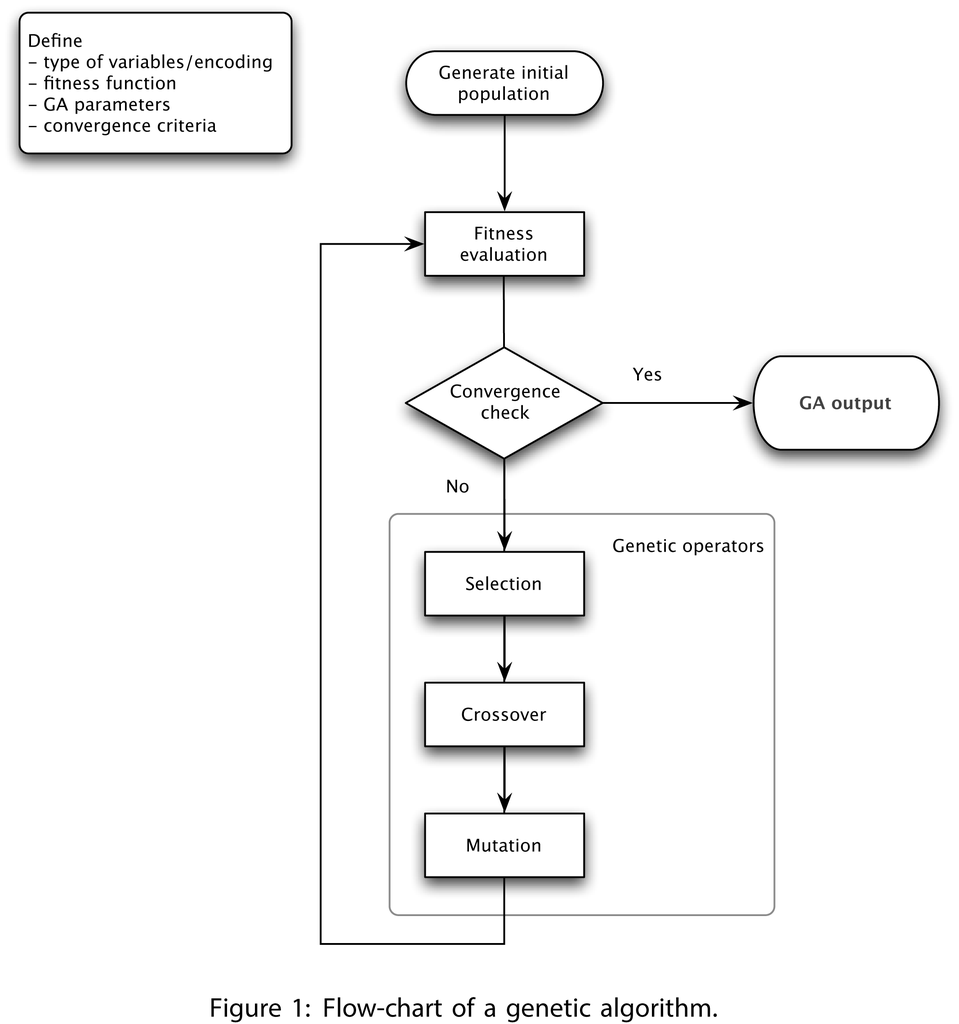

We’ll start by trying to optimize this now-familiar toy function:

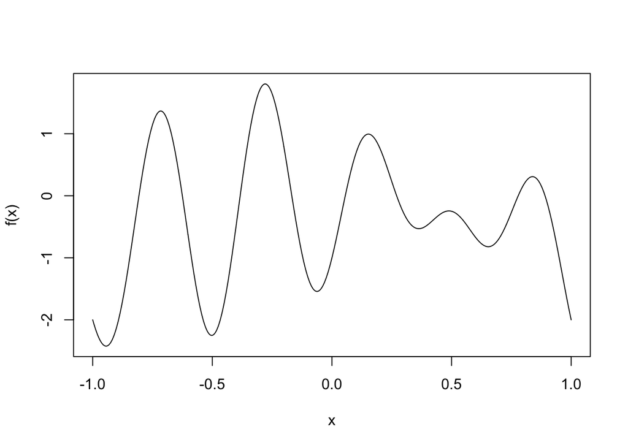

```r
f <- function(x) -x^2 + sin(x * 5 * pi) - cos(x * 4 * pi)
x <- seq(-1, 1, l=1e3)
plot(x, f(x), type = "l")
```

## Population

The first step in a GA is to initialize the population. This can be done completely at random, or could be based on *a priori* information. The default method in the `GA` package is to sample the initial population uniformly from the parameter space.

```r
library(GA)
set.seed(1234)
pop_size <- 8 ## we'll choose a very small population for the purposes of exploration
example_ga <- ga(type = "real-valued", fitness = f, lower = -1, upper = 1,
                 popSize = pop_size, maxiter = 1)
example_ga@population
```

```
##             [,1]
## [1,] -0.36677509
## [2,] -0.39461326
## [3,] -0.68190799
## [4,] -0.92000816
## [5,] -0.56240092
## [6,]  0.62119710
## [7,]  0.05139509
## [8,]  0.82931633
```

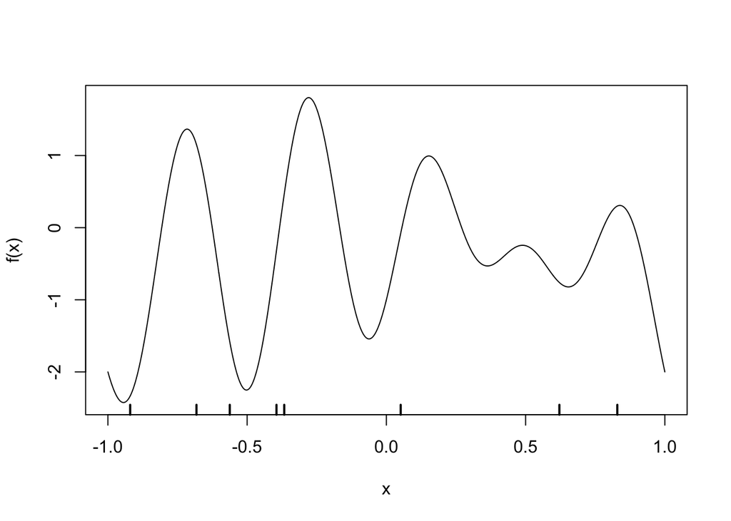

```r
plot(x, f(x), type = "l")
rug(example_ga@population, lwd = 2)
```

## Selection

Next, we evaluate the function, $f$, for each individual in the population and choose which individuals are successful at reproducing based on their relative values. Higher points on the curve are more likely to be selected, and some points maybe be selected several times.

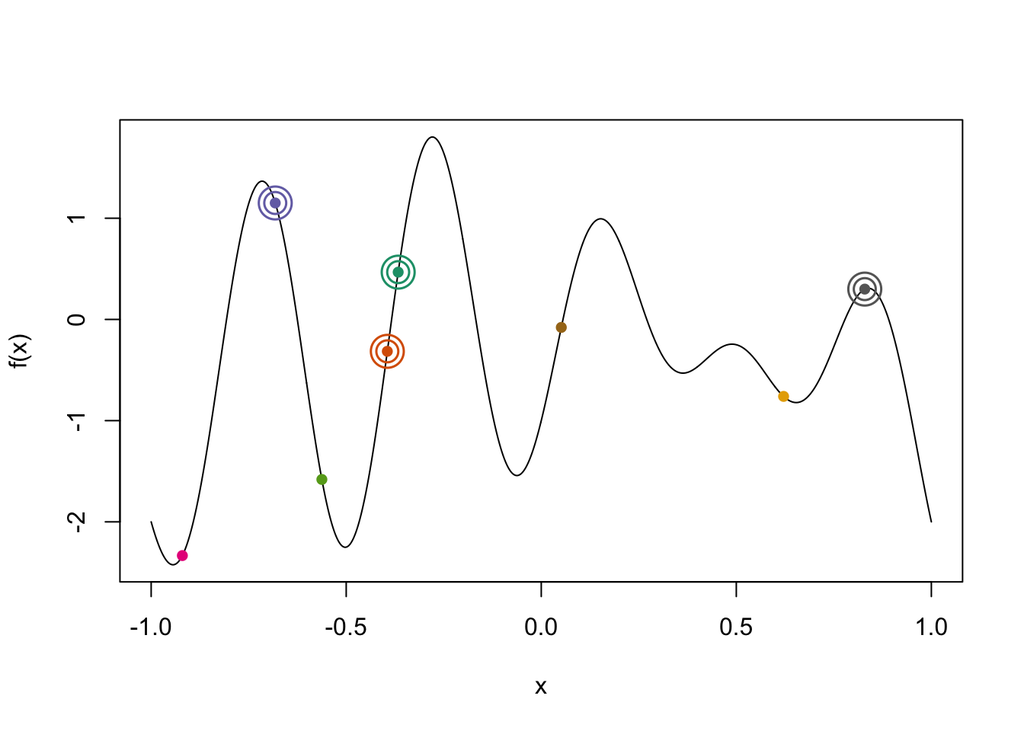

```r
selected <- gareal_lsSelection(example_ga)
selected_ind <- sapply(selected$population, function(sel) min(which(sel == example_ga@population)))
ring_size <- c(1, 1 + sapply(2:length(selected_ind), function(i){
  sum(selected_ind[i] == selected_ind[1:(i - 1)])
}))
n_repeats <- sapply(unique(selected_ind), function(ind) sum(ind == selected_ind))
pop_cols <- RColorBrewer::brewer.pal(pop_size, "Dark2")
plot(x, f(x), type = "l")
points(example_ga@population, example_ga@fitness, pch = 16, col = pop_cols)
points(selected$population, selected$fitness, col = pop_cols[selected_ind], cex = ring_size + 1, lwd = 1.5)
```

## Crossover

After we’ve picked which individuals get to reproduce, we match them up in pairs at random and let the parents create 2 offspring. Certain individuals will get to parent several offspring because they were picked multiple times in the selection stage. It is even possible for an individual to get matched with itself.

The next graph shows what happens for a single pair of parents.

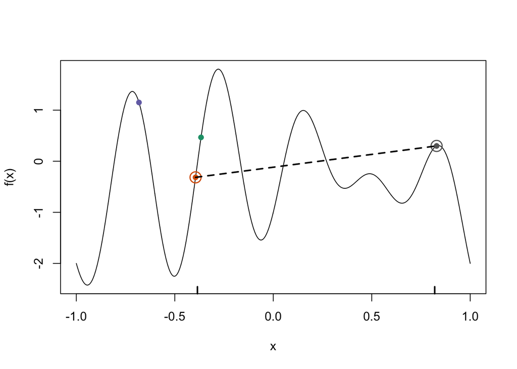

```r
example_ga@population <- selected$population
example_ga@fitness <- selected$fitness
parents <- sample(selected_ind, 2)
plot(x, f(x), type = "l")
points(example_ga@population, example_ga@fitness, pch = 16, col = pop_cols[selected_ind])
points(example_ga@population[parents], example_ga@fitness[parents],
       lwd = 1.5, pch = 1, cex = 2, col = pop_cols[selected_ind[parents]])
lines(example_ga@population[parents], example_ga@fitness[parents], lwd = 2, lty = 2)
rug(gareal_laCrossover(example_ga, parents)$children, lwd = 2)
```

The next graph shows what happens for all 4 pairs of parents.

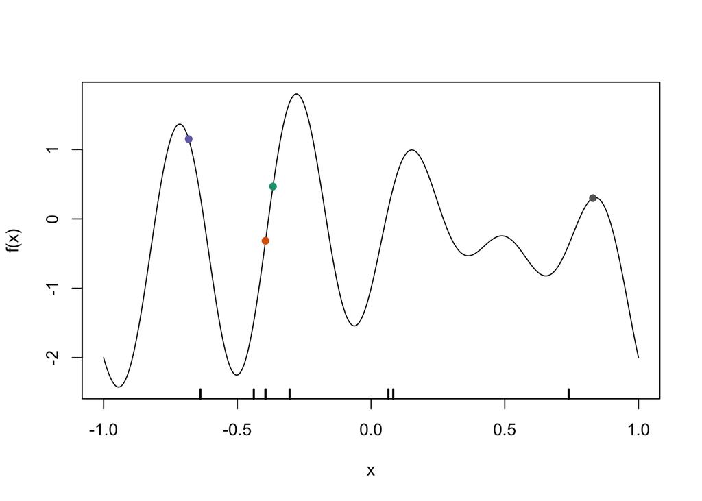

```r
parent_mat <- matrix(sample(selected_ind, size = pop_size), nrow = 2)
crossed <- c(apply(parent_mat, 2, function(parents){
  if(runif(1) < 0.8){
    gareal_laCrossover(example_ga, parents)$children
  } else {
    example_ga@population[parents]
  }
}))
plot(x, f(x), type = "l")
points(example_ga@population, example_ga@fitness, pch = 16, col = pop_cols[selected_ind])
rug(crossed, lwd = 2)
```

## Mutation

Limiting evolution only to crossover can lead to degeneracy. The offspring can start to look a lot like the parents, and eventually we lose diversity in the population. This can lead to the same problems as deterministic optimization (e.g., stuck in local modes). Introducing a small amount of extra randomness, or *mutation*, can help keep the algorithm from getting stuck.

The amount of mutation introduced in the algorithm is yet another parameter to be tuned. Too much, and the population won’t “learn” the best parts of the parameters space, but too little and our algorithm could get stuck. The default in `GA` is to mutate each of the new offspring with probability 0.1. Mutation can be defined several ways, but the default in `GA` is just to draw a new variable uniformly from the parameter space. For multi-variate problems, this can be done separately for each variable.

```r
gareal_raMutation(example_ga, 1)
```

```
## [1] -0.6507004
```

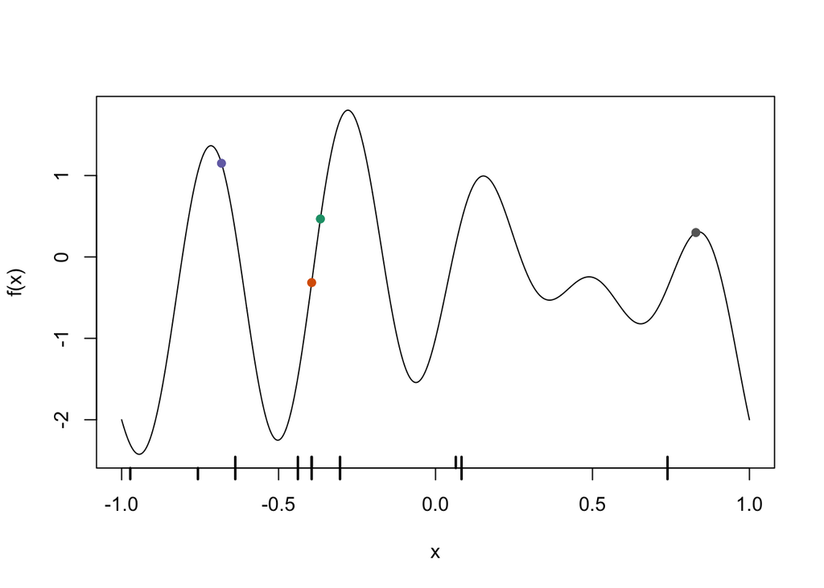

```r
mutated <- crossed
for(i in 1:pop_size){
  if(runif(1) < 0.1){
    mutated[i] <- gareal_raMutation(example_ga, parent = 1)
  }
}
plot(x, f(x), type = "l")
points(example_ga@population, example_ga@fitness, pch = 16, col = pop_cols[selected_ind])
rug(crossed, lwd = 2)
rug(mutated, lwd = 2, -0.03)
```

## Putting it all together

In practice, we don’t need to walk through all the steps one by one. The `GA` package does all this automatically and with decent defaults. The package has support for a `monitor()` function, which can help show how things are progressing, but it’s not usually necessary to specify such a function. I used it below to make an animation of the process for 10 individuals over 100 iterations.

```r
monitor <- function(obj){
  plot(x, f(x), type = "l")
  points(obj@population, obj@fitness, cex = seq(0.82, 1.18, l = 10))
}
opt_ga <- ga(type = "real-valued", fitness = f, lower = -1, upper = 1, popSize = 10, maxiter = 100, monitor = monitor)
```

[video not shown]

The procedure can also be summarized with a static plot that shows how the population evolves over time.

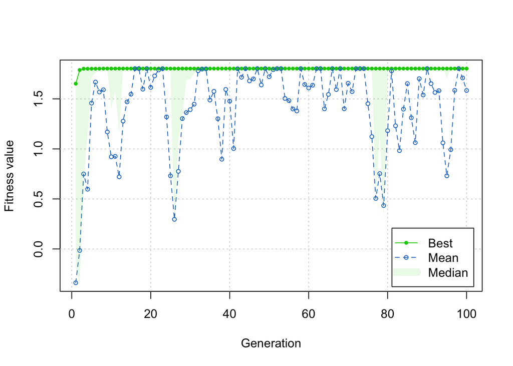

```r
opt_ga <- ga(type = "real-valued", fitness = f, lower = -1, upper = 1, popSize = 10, maxiter = 100)
plot(opt_ga)
```

## A multivariate example

We return to the mixture distribution problem, which we recall was multi-modal and had a saddle that sometimes tricked deterministic optimization methods (see Optimization slides for details).

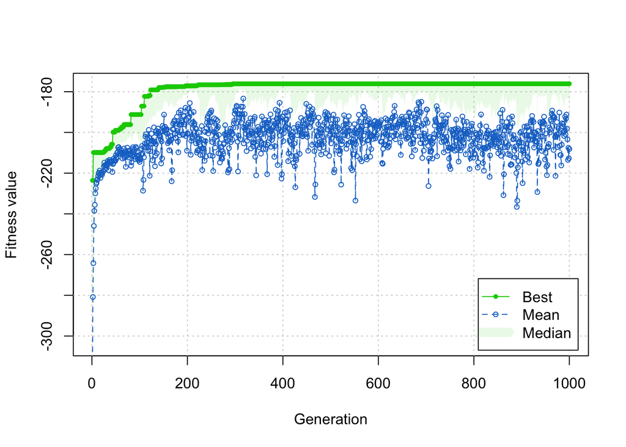

```r
mus <- c(-2, 2)
sigmas <- c(1, 1/2)
p <- 0.7
theta <- c(mu = mus, sigma = sigmas, p = p)
n <- 1e2
z <- sample(1:2, size = n, prob = c(p, 1 - p), replace = T)
X <- rnorm(n, mean = mus[z], sd = sigmas[z])
mixture_ll <- function(X, mus, sigmas, p, log = T){
  out <- sum(log(p * dnorm(X, mus[1], sigmas[1]) +
                   (1 - p) * dnorm(X, mus[2], sigmas[2])))
  if(!log) return(exp(out))
  return(out)
}
mixture_ga <- ga(type = "real-valued", fitness = function(theta, X){
  mixture_ll(X = X, mus = theta[1:2], sigmas = theta[3:4], p = theta[5])},
  X = X, lower = c(-6, -6, 0, 0, 0), upper = c(6, 6, 10, 10, 1),
  popSize = 100, maxiter = 1000, pmutation = 0.1, monitor = F)
plot(mixture_ga)
```

```r
mixture_ga@solution
```

```
##            x1        x2        x3        x4       x5
## [1,] 2.110646 -1.845708 0.4865046 0.9489866 0.352273
```

```r
theta
```

```
##    mu1    mu2 sigma1 sigma2      p
##   -2.0    2.0    1.0    0.5    0.7
```

## Best of both worlds?

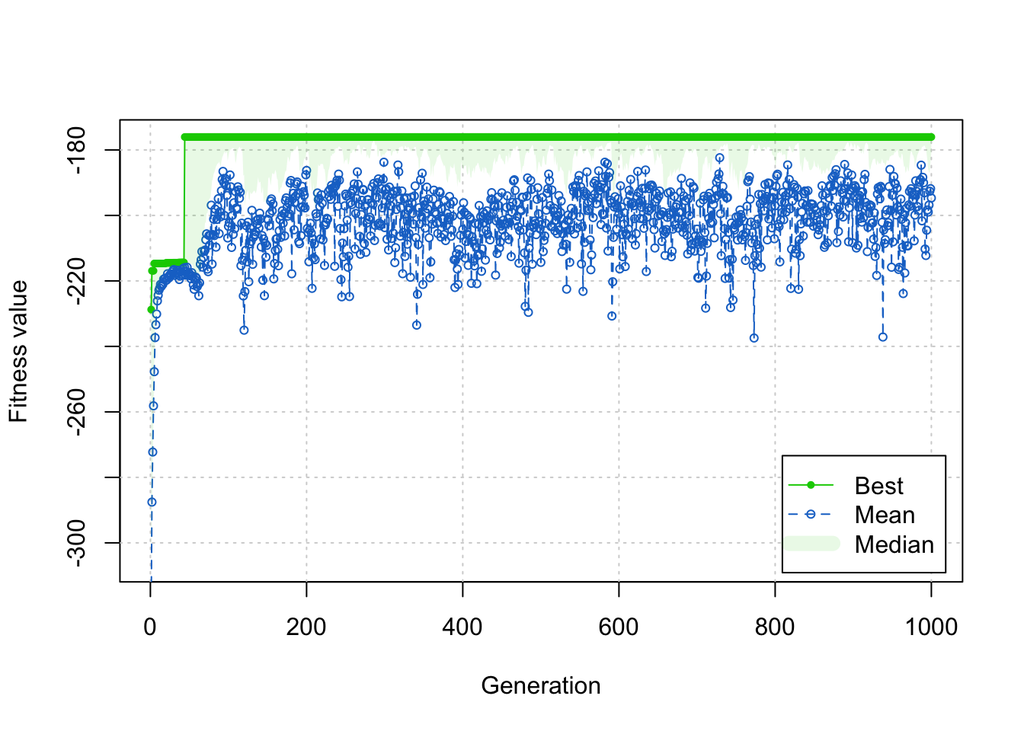

```r
mixture_ga_optim <- ga(type = "real-valued", fitness = function(theta, X){
  mixture_ll(X = X, mus = theta[1:2], sigmas = theta[3:4], p = theta[5])},
  X = X, lower = c(-6, -6, 0, 0, 0), upper = c(6, 6, 10, 10, 1), optim = T,
  popSize = 100, maxiter = 1000, pmutation = 0.1, monitor = F)
plot(mixture_ga_optim)
```

```r
mixture_ga_optim@solution
```

```
##            x1        x2        x3        x4        x5
## [1,] 2.130751 -1.838514 0.4686031 0.9548861 0.3515953
```

```r
theta
```

```
##    mu1    mu2 sigma1 sigma2      p
##   -2.0    2.0    1.0    0.5    0.7
```

[^1]: Scrucca, L. (2013). GA: a package for genetic algorithms in R. Journal of Statistical Software, 53(4), 1-37.